# Part I - U.S. Domestic Flights Data Exploration

## Introduction

**The dataset under investigation is the [T_ONTIME_REPORTING.csv](https://www.transtats.bts.gov/DL_SelectFields.aspx?gnoyr_VQ=FGJ&QO_fu146_anzr=b0-gvzr), which contains flight-level records including departure and arrival times, delays, cancellations, diversions, and distances between airports. The aim of this exploration is to analyze patterns in flight delays, cancellations, and diversions, and to understand how these variables interact with factors such as departure hour, day of the week, and flight distance.**

## Preliminary Wrangling

```python
# import all packages and set plots to be embedded inline
import numpy as np
import pandas as pd
import matplotlib.pyplot as plt
import seaborn as sns
import datetime
```

```python
# Load dataset
df = pd.read_csv("T_ONTIME_REPORTING.csv")
```

```python
df.shape
```

```
(539747, 11)
```

```python
#overview
df.head()
```

|  | FL_DATE | ORIGIN | DEST | DEP_TIME | DEP_DELAY | ARR_TIME | ARR_DELAY | ARR_DELAY_NEW | CANCELLED | DIVERTED | DISTANCE |
| --- | --- | --- | --- | --- | --- | --- | --- | --- | --- | --- | --- |
| 0 | 1/1/2025 12:00:00 AM | ABE | CLT | 556.0 | -10.0 | 736.0 | -36.0 | 0.0 | 0.0 | 0.0 | 481.0 |
| 1 | 1/1/2025 12:00:00 AM | ABE | CLT | 1215.0 | -4.0 | 1405.0 | -12.0 | 0.0 | 0.0 | 0.0 | 481.0 |
| 2 | 1/1/2025 12:00:00 AM | ABE | CLT | 1730.0 | -8.0 | 1920.0 | -14.0 | 0.0 | 0.0 | 0.0 | 481.0 |
| 3 | 1/1/2025 12:00:00 AM | ABE | PGD | 820.0 | -10.0 | 1127.0 | -3.0 | 0.0 | 0.0 | 0.0 | 1018.0 |
| 4 | 1/1/2025 12:00:00 AM | ABE | PIE | 1547.0 | -4.0 | 1837.0 | -13.0 | 0.0 | 0.0 | 0.0 | 970.0 |

```python
df.info()
```

```
<class 'pandas.core.frame.DataFrame'>
RangeIndex: 539747 entries, 0 to 539746
Data columns (total 11 columns):
 #   Column         Non-Null Count   Dtype
---  ------         --------------   -----
 0   FL_DATE        539747 non-null  object
 1   ORIGIN         539747 non-null  object
 2   DEST           539747 non-null  object
 3   DEP_TIME       523861 non-null  float64
 4   DEP_DELAY      523824 non-null  float64
 5   ARR_TIME       523167 non-null  float64
 6   ARR_DELAY      522269 non-null  float64
 7   ARR_DELAY_NEW  522269 non-null  float64
 8   CANCELLED      539747 non-null  float64
 9   DIVERTED       539747 non-null  float64
 10  DISTANCE       539747 non-null  float64
dtypes: float64(8), object(3)
memory usage: 45.3+ MB
```

We have a problem with `FL_DATE`, `DEP_TIME`, and `ARR_TIME` as they are not in the correct datetime format.

```python
# Convert flight date to datetime
df['FL_DATE'] = pd.to_datetime(df['FL_DATE'])
```

```python
# Convert HHMM integer time to string HH:MM
def convert_to_time(val):
    if pd.isnull(val):
        return np.nan
    val = int(val)
    hh = val // 100
    mm = val % 100
    # Handle 2400 as 00:00
    if hh == 24 and mm == 0:
        hh = 0
    return f"{hh:02d}:{mm:02d}"



df['DEP_TIME'] = df['DEP_TIME'].apply(convert_to_time)
df['ARR_TIME'] = df['ARR_TIME'].apply(convert_to_time)
```

```python
df.head()
```

|  | FL_DATE | ORIGIN | DEST | DEP_TIME | DEP_DELAY | ARR_TIME | ARR_DELAY | ARR_DELAY_NEW | CANCELLED | DIVERTED | DISTANCE |
| --- | --- | --- | --- | --- | --- | --- | --- | --- | --- | --- | --- |
| 0 | 2025-01-01 | ABE | CLT | 05:56 | -10.0 | 07:36 | -36.0 | 0.0 | 0.0 | 0.0 | 481.0 |
| 1 | 2025-01-01 | ABE | CLT | 12:15 | -4.0 | 14:05 | -12.0 | 0.0 | 0.0 | 0.0 | 481.0 |
| 2 | 2025-01-01 | ABE | CLT | 17:30 | -8.0 | 19:20 | -14.0 | 0.0 | 0.0 | 0.0 | 481.0 |
| 3 | 2025-01-01 | ABE | PGD | 08:20 | -10.0 | 11:27 | -3.0 | 0.0 | 0.0 | 0.0 | 1018.0 |
| 4 | 2025-01-01 | ABE | PIE | 15:47 | -4.0 | 18:37 | -13.0 | 0.0 | 0.0 | 0.0 | 970.0 |

### What is the structure of your dataset?

Number of rows and columns: (`539,747`, `11`)

Key columns: `FL_DATE`, `ORIGIN`, `DEST`, `DEP_TIME`, `DEP_DELAY`, `ARR_TIME`, `ARR_DELAY`, `CANCELLED`, `DIVERTED`, `DISTANCE`

Data types: Mixed; dates were converted to datetime, times to HH:MM format, and delays separated into late and early arrivals.

### What is/are the main feature(s) of interest in your dataset?

`ARR_DELAY`: arrival delay

`CANCELLED`: flight cancellation indicator

`DIVERTED` : flight diversion indicator

### What features in the dataset do you think will help support your investigation into your feature(s) of interest?

`DEP_HOUR` : departure hour

`DAY_OF_WEEK` : derived from FL_DATE

`DISTANCE` : flight distance

## Univariate Exploration

How are flights distributed by day of month?

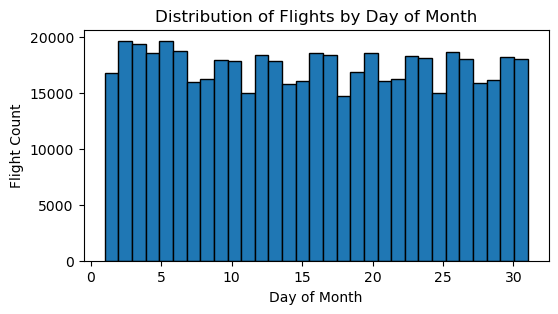

```python
df['DAY_OF_MONTH'] = df['FL_DATE'].dt.day
plt.figure(figsize=(6,3))
plt.hist(df['DAY_OF_MONTH'], bins=31, edgecolor='black')
plt.xlabel("Day of Month")
plt.ylabel("Flight Count")
plt.title("Distribution of Flights by Day of Month")
plt.show()
```

**The number of flights is higher at the start of the month and fluctuates slightly throughout. The elevated count early in January may reflect increased travel due to New Year holidays.**

How many flights were cancelled?

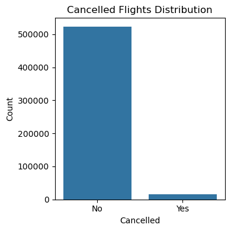

```python
# convert CANCELLED to readable labels
cancelled_labels = df['CANCELLED'].replace({0.0: 'No', 1.0: 'Yes'})

# Set figure size before plotting
plt.figure(figsize=(4, 4))  # Adjust dimensions as needed

sns.countplot(x=cancelled_labels, color='#1f77b4')  # default Seaborn blue
plt.xlabel("Cancelled")
plt.ylabel("Count")
plt.title("Cancelled Flights Distribution")
plt.tight_layout()  # Avoid label cut-off
plt.show()
```

**Cancelled flights constitute a small fraction of total flights compared to non-cancelled flights.**

### Discuss the distribution(s) of your variable(s) of interest. Were there any unusual points? Did you need to perform any transformations?

> The distribution of flights by day of the month is relatively uniform, with only slight fluctuations across days and a modest increase in activity at the beginning of January, likely related to post–New Year travel demand. No unusual outliers were observed in this distribution, and no transformations were required since the variable is already in an appropriate numeric format. For cancellations, the distribution is highly imbalanced: the vast majority of flights were not cancelled, with only a very small fraction showing cancellation. This result is consistent with expectations for commercial flight operations. No transformations were necessary, though the binary values were recoded (0 → "No", 1 → "Yes") for interpretability in plots.

## Bivariate Exploration

New columns for departure and arrival hours, as well as separate late and early arrival delays, were created to enable clear, time-based analysis of flight performance and to examine patterns in delays and diversions effectively.

```python
# Function: Extract hour from time string
def extract_hour(df, col_name, new_col_name):

    df[new_col_name] = pd.to_datetime(df[col_name], format="%H:%M", errors='coerce').dt.hour
    return df

# Use the function
df = extract_hour(df, 'DEP_TIME', 'DEP_HOUR')
df = extract_hour(df, 'ARR_TIME', 'ARR_HOUR')
```

```python
def split_delays(df, col_name):
    base = col_name.split('_')[0]
    df[f"{base}_Late"] = df[col_name].apply(lambda x: x if x > 0 else 0)
    df[f"{base}_Early"] = df[col_name].apply(lambda x: -x if x < 0 else 0)
    return df

df = split_delays(df, 'ARR_DELAY')
```

How does departure hour relate to late and early arrivals?

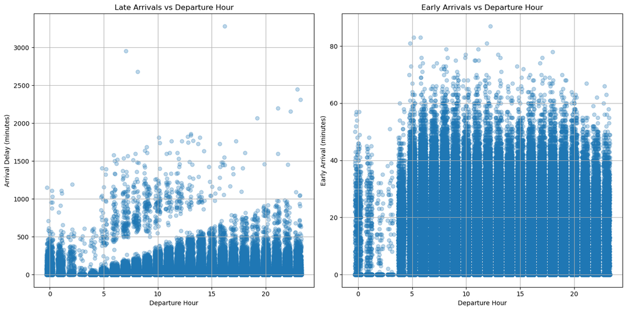

```python
# Function: Reusable regplot with jitter
def regplot_with_jitter(df, x_col, y_col,scatter_color='#1f77b4', alpha=0.3, x_jitter=0.3, xlabel=None, ylabel=None, title=None):
    sns.regplot(
        data=df,
        x=x_col,
        y=y_col,
        x_jitter=x_jitter,
        scatter_kws={'alpha':alpha, 'color':scatter_color},
        fit_reg=False
    )
    if xlabel: plt.xlabel(xlabel)
    if ylabel: plt.ylabel(ylabel)
    if title: plt.title(title)
    plt.grid(True)

# Two-panel plot: DEP_HOUR vs Late/Early Arrival
plt.figure(figsize=(14,7))

plt.subplot(1, 2, 1)
regplot_with_jitter(df, x_col='DEP_HOUR', y_col='ARR_Late',
                    xlabel='Departure Hour', ylabel='Arrival Delay (minutes)', title='Late Arrivals vs Departure Hour')

plt.subplot(1, 2, 2)
regplot_with_jitter(df, x_col='DEP_HOUR', y_col='ARR_Early',
                    xlabel='Departure Hour', ylabel='Early Arrival (minutes)', title='Early Arrivals vs Departure Hour')

plt.tight_layout()
plt.show()
```

How does diversion affect departure hour?

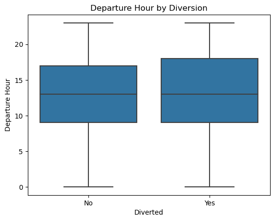

```python
sns.boxplot(
    x=df['DIVERTED'].replace({0.0: 'No', 1.0: 'Yes'}),
    y='DEP_HOUR',
    data=df,
    color='#1f77b4'
)
plt.xlabel("Diverted")
plt.ylabel("Departure Hour")
plt.title("Departure Hour by Diversion")
plt.show()
```

**No extreme outliers are observed. Flights that were diverted tend to depart slightly later than non-diverted flights. The difference is minor, but it indicates a potential impact of diversion on scheduling.**

Early vs. Late Arrivals by Day of Week?

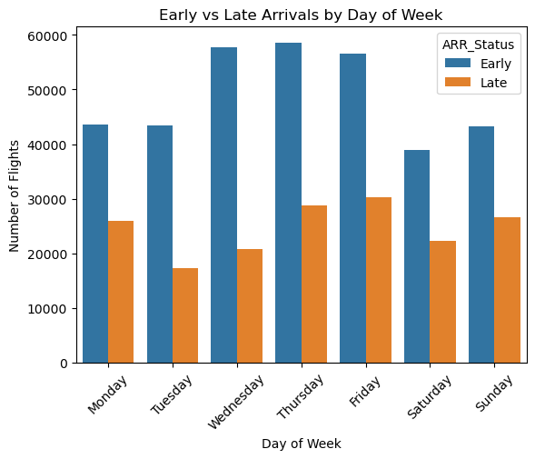

```python
# Extract day of week from flight date
df['DAY_OF_WEEK'] = pd.to_datetime(df['FL_DATE']).dt.day_name()

df['ARR_Status'] = df['ARR_DELAY'].apply(
    lambda x: 'Early' if x < 0 else ('Late' if x > 0 else np.nan)
)

# Group by day of week and arrival status
status_by_day = df.groupby(['DAY_OF_WEEK','ARR_Status']).size().reset_index(name='counts')

# Order days correctly
day_order = ['Monday', 'Tuesday', 'Wednesday', 'Thursday', 'Friday', 'Saturday', 'Sunday']

# Plot
sns.barplot(
    x="DAY_OF_WEEK",
    y="counts",
    hue="ARR_Status",
    data=status_by_day,
    order=day_order
)

plt.xlabel("Day of Week")
plt.ylabel("Number of Flights")
plt.title("Early vs Late Arrivals by Day of Week")
plt.xticks(rotation=45)
plt.show()
```

### Talk about some of the relationships you observed in this part of the investigation. How did the feature(s) of interest vary with other features in the dataset?

> Departure hour demonstrates a clear relationship with arrival delays: flights departing during early morning hours show a higher likelihood of being late, while peak daytime departures exhibit moderate late arrivals. Diversions are associated with certain departure times but remain relatively rare. Patterns of early and late arrivals also vary systematically by day of the week, reflecting operational or scheduling trends that influence punctuality.

## Multivariate Exploration

what are the average late arrival by Departure Time and day of week?

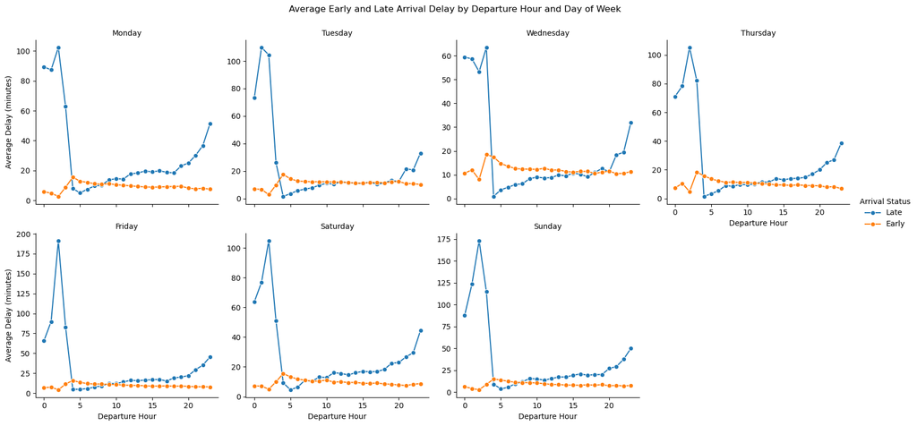

```python
# Aggregate data: average Early and Late by DEP_HOUR and DAY_OF_WEEK
agg = df.groupby(['DAY_OF_WEEK','DEP_HOUR'])[['ARR_Late','ARR_Early']].mean().reset_index()

# Melt into long format for hue
agg_melt = agg.melt(id_vars=['DAY_OF_WEEK','DEP_HOUR'],
                    value_vars=['ARR_Late','ARR_Early'],
                    var_name='ARR_Stat', value_name='Average_Delay')

# Rename for readability
agg_melt['ARR_Stat'] = agg_melt['ARR_Stat'].replace({'ARR_Late':'Late', 'ARR_Early':'Early'})

# Ensure days are ordered
day_order = ['Monday','Tuesday','Wednesday','Thursday','Friday','Saturday','Sunday']
agg_melt['DAY_OF_WEEK'] = pd.Categorical(agg_melt['DAY_OF_WEEK'], categories=day_order, ordered=True)

# FacetGrid with hue
g = sns.FacetGrid(agg_melt, col='DAY_OF_WEEK', col_wrap=4, height=4, hue='ARR_Stat', sharey=False)
g.map_dataframe(sns.lineplot, x='DEP_HOUR', y='Average_Delay', marker='o')
g.set_axis_labels("Departure Hour", "Average Delay (minutes)")
g.set_titles(col_template="{col_name}")
g.add_legend(title="Arrival Status")
plt.subplots_adjust(top=0.9)
g.fig.suptitle("Average Early and Late Arrival Delay by Departure Hour and Day of Week")
plt.show()
```

**Late arrivals show a clear concentration in the early morning, particularly before 5 AM, suggesting that overnight and pre-dawn operations face higher disruption risks. After 5 AM, delays begin to rise gradually across the day, likely reflecting accumulated scheduling pressures and traffic congestion.**

**In contrast, early arrivals are relatively less common before 4 AM, but they peak between 4 and 5 AM, indicating that flights departing in the early morning window are more likely to benefit from lighter traffic and favorable conditions that enable them to arrive ahead of schedule.**

How does departure hour and flight distance relate to late arrivals?

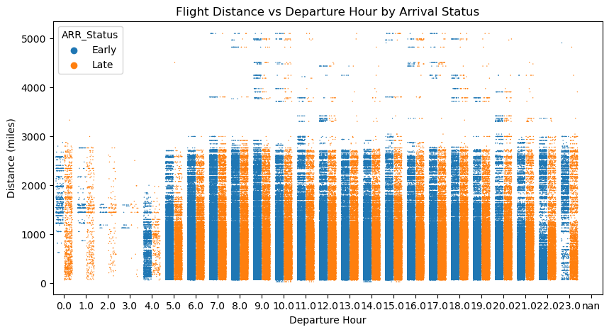

```python
# Scatterplot: Distance vs Departure Hour, hue = arrival status
plt.figure(figsize=(10,5))
sns.stripplot(
    data=df,
    x='DEP_HOUR',
    y='DISTANCE',
    hue='ARR_Status',
    dodge=True,
    jitter=0.35,
    size=1
)

plt.xlabel("Departure Hour")
plt.ylabel("Distance (miles)")
plt.title("Flight Distance vs Departure Hour by Arrival Status")
plt.show()
```

## Conclusions

> The exploration of the T_ONTIME_REPORTING dataset revealed patterns in flight delays, cancellations, and diversions, and how these relate to departure time, day of the week, and flight distance. Early and late arrivals, departure hours, and flight distance showed clear relationships with punctuality, while cancellations and diversions, though rare, highlighted operational trends. Multivariate analyses emphasized that multiple factors interact to influence flight performance, showing that considering features together provides a clearer understanding of delays and operational patterns. Overall, the analysis provides insight into how temporal and operational factors impact airline performance.

```python
# save the df :
df.to_csv("processed_flights.csv", index=False)
```